# Case_Study3_Romain_Kursner_and_Lan_Hoang

KURSNER Romain & HOANG Lan

19/5/2022

# Advanced Data Driven Decision Making.

## Case Study 3.

```r
rm(list = ls()) #Clear the environment.
cat("\014") #Clear the console.
```

```r
data =read.csv("Case Study III_Structural Equation Modeling.csv") #Download the data.
```

### Libraries.

```r
library(ggplot2)
library(naniar)
library(corrplot)
library(Hmisc) #to calculate p-value of correlation matrix
library(ellipse)
library(gplots)
library(psych)
library(REdaS)
library(nFactors)
library(FactoMineR)
library(factoextra)
library(lavaan)
library(psy)
library(knitr)
library(semPlot)
library(dplyr)
```

### Data exploration.

We explore the data to see if there are any missing values.

```r
summary(data)
```

```
##       Im1              Im2              Im3              Im4
##  Min.   :  1.00   Min.   :  1.00   Min.   :  1.00   Min.   :  1.00
##  1st Qu.:  4.00   1st Qu.:  4.00   1st Qu.:  4.00   1st Qu.:  4.00
##  Median :  5.00   Median :  5.00   Median :  5.00   Median :  5.00
##  Mean   : 29.96   Mean   : 37.21   Mean   : 40.93   Mean   : 22.98
##  3rd Qu.:  6.00   3rd Qu.:  6.00   3rd Qu.:  6.00   3rd Qu.:  6.00
##  Max.   :999.00   Max.   :999.00   Max.   :999.00   Max.   :999.00
##       Im5              Im6              Im7              Im8
##  Min.   :  1.00   Min.   :  1.00   Min.   :  2.00   Min.   :  1.00
##  1st Qu.:  4.00   1st Qu.:  5.00   1st Qu.:  5.00   1st Qu.:  6.00
##  Median :  5.00   Median :  6.00   Median :  6.00   Median :  6.00
##  Mean   : 57.16   Mean   : 21.99   Mean   : 52.45   Mean   : 16.77
##  3rd Qu.:  6.00   3rd Qu.:  7.00   3rd Qu.:  7.00   3rd Qu.:  7.00
##  Max.   :999.00   Max.   :999.00   Max.   :999.00   Max.   :999.00
##       Im9              Im10             Im11             Im12
##  Min.   :  1.00   Min.   :  2.00   Min.   :  1.00   Min.   :  1.00
##  1st Qu.:  4.00   1st Qu.:  6.00   1st Qu.:  5.00   1st Qu.:  5.00
##  Median :  5.00   Median :  6.00   Median :  6.00   Median :  6.00
##  Mean   : 33.83   Mean   : 16.88   Mean   : 27.21   Mean   : 43.39
##  3rd Qu.:  6.00   3rd Qu.:  7.00   3rd Qu.:  6.00   3rd Qu.:  7.00
##  Max.   :999.00   Max.   :999.00   Max.   :999.00   Max.   :999.00
##       Im13             Im14             Im15             Im16
##  Min.   :  1.00   Min.   :  1.00   Min.   :  1.00   Min.   :  1.00
##  1st Qu.:  5.00   1st Qu.:  6.00   1st Qu.:  4.00   1st Qu.:  4.00
##  Median :  6.00   Median :  6.00   Median :  5.00   Median :  5.00
##  Mean   : 32.39   Mean   : 49.23   Mean   : 26.67   Mean   : 48.26
##  3rd Qu.:  6.00   3rd Qu.:  7.00   3rd Qu.:  6.00   3rd Qu.:  6.00
##  Max.   :999.00   Max.   :999.00   Max.   :999.00   Max.   :999.00
##       Im17             Im18             Im19             Im20
##  Min.   :  1.00   Min.   :  1.00   Min.   :  1.00   Min.   :  1.00
##  1st Qu.:  4.00   1st Qu.:  4.00   1st Qu.:  4.00   1st Qu.:  4.00
##  Median :  5.00   Median :  5.00   Median :  5.00   Median :  5.00
##  Mean   : 26.59   Mean   : 54.92   Mean   : 26.71   Mean   : 20.85
##  3rd Qu.:  6.00   3rd Qu.:  6.00   3rd Qu.:  6.00   3rd Qu.:  6.00
##  Max.   :999.00   Max.   :999.00   Max.   :999.00   Max.   :999.00
##       Im21             Im22            C_CR1            C_CR2
##  Min.   :  1.00   Min.   :  1.00   Min.   :  1.00   Min.   :  1.00
##  1st Qu.:  4.00   1st Qu.:  3.00   1st Qu.:  1.00   1st Qu.:  4.00
##  Median :  6.00   Median :  4.00   Median :  2.00   Median :  5.00
##  Mean   : 14.12   Mean   : 34.87   Mean   : 38.71   Mean   : 58.56
```

[output cut: 29 more lines]

```
##  Max.   :999.0   Max.   :999.00   Max.   :999.00   Max.   :999.00
##      SAT_P5           SAT_P6           TRU_1            TRU_2
##  Min.   :  1.00   Min.   :  1.00   Min.   :  1.00   Min.   :  1.00
##  1st Qu.:  4.00   1st Qu.:  5.00   1st Qu.:  3.00   1st Qu.:  4.00
##  Median :  6.00   Median :  6.00   Median :  5.00   Median :  5.00
##  Mean   : 19.67   Mean   : 28.99   Mean   : 54.73   Mean   : 64.43
##  3rd Qu.:  6.00   3rd Qu.:  7.00   3rd Qu.:  6.00   3rd Qu.:  6.00
##  Max.   :999.00   Max.   :999.00   Max.   :999.00   Max.   :999.00
##      TRU_3
##  Min.   :  1.00
##  1st Qu.:  5.00
##  Median :  6.00
##  Mean   : 55.77
##  3rd Qu.:  6.00
##  Max.   :999.00
```

As mentioned in the seminar, the value `999` represents missing values. To avoid this numeric value from being taken account in our models, we will convert this value to NA.

```r
data_new =data.frame(sapply(data,function(x) ifelse((x==999),NA,x)))

summary(data_new)
```

```
##       Im1             Im2             Im3             Im4             Im5
##  Min.   :1.000   Min.   :1.000   Min.   :1.000   Min.   :1.000   Min.   :1.00
##  1st Qu.:4.000   1st Qu.:4.000   1st Qu.:4.000   1st Qu.:4.000   1st Qu.:4.00
##  Median :5.000   Median :5.000   Median :5.000   Median :5.000   Median :5.00
##  Mean   :4.792   Mean   :4.854   Mean   :4.985   Mean   :5.002   Mean   :5.04
##  3rd Qu.:6.000   3rd Qu.:6.000   3rd Qu.:6.000   3rd Qu.:6.000   3rd Qu.:6.00
##  Max.   :7.000   Max.   :7.000   Max.   :7.000   Max.   :7.000   Max.   :7.00
##  NA's   :14      NA's   :18      NA's   :20      NA's   :10      NA's   :29
##       Im6             Im7            Im8             Im9             Im10
##  Min.   :1.000   Min.   :2.00   Min.   :1.000   Min.   :1.000   Min.   :2.000
##  1st Qu.:5.000   1st Qu.:5.00   1st Qu.:6.000   1st Qu.:4.000   1st Qu.:6.000
##  Median :6.000   Median :6.00   Median :6.000   Median :5.000   Median :6.000
##  Mean   :5.824   Mean   :5.75   Mean   :5.996   Mean   :5.076   Mean   :6.102
##  3rd Qu.:7.000   3rd Qu.:7.00   3rd Qu.:7.000   3rd Qu.:6.000   3rd Qu.:7.000
##  Max.   :7.000   Max.   :7.00   Max.   :7.000   Max.   :7.000   Max.   :7.000
##  NA's   :9       NA's   :26     NA's   :6       NA's   :16      NA's   :6
##       Im11            Im12            Im13            Im14
##  Min.   :1.000   Min.   :1.000   Min.   :1.000   Min.   :1.000
##  1st Qu.:5.000   1st Qu.:5.000   1st Qu.:5.000   1st Qu.:6.000
##  Median :6.000   Median :6.000   Median :6.000   Median :6.000
##  Mean   :5.654   Mean   :5.665   Mean   :5.444   Mean   :6.144
##  3rd Qu.:6.000   3rd Qu.:6.000   3rd Qu.:6.000   3rd Qu.:7.000
##  Max.   :7.000   Max.   :7.000   Max.   :7.000   Max.   :7.000
##  NA's   :12      NA's   :21      NA's   :15      NA's   :24
##       Im15            Im16           Im17            Im18            Im19
##  Min.   :1.000   Min.   :1.00   Min.   :1.000   Min.   :1.000   Min.   :1.000
##  1st Qu.:4.000   1st Qu.:4.00   1st Qu.:4.000   1st Qu.:4.000   1st Qu.:4.000
##  Median :5.000   Median :5.00   Median :5.000   Median :5.000   Median :5.000
##  Mean   :5.098   Mean   :5.13   Mean   :5.018   Mean   :4.571   Mean   :5.148
##  3rd Qu.:6.000   3rd Qu.:6.00   3rd Qu.:6.000   3rd Qu.:6.000   3rd Qu.:6.000
##  Max.   :7.000   Max.   :7.00   Max.   :7.000   Max.   :7.000   Max.   :7.000
##  NA's   :12      NA's   :24     NA's   :12      NA's   :28      NA's   :12
##       Im20            Im21            Im22           C_CR1
##  Min.   :1.000   Min.   :1.000   Min.   :1.000   Min.   :1.000
##  1st Qu.:4.000   1st Qu.:4.000   1st Qu.:3.000   1st Qu.:1.000
##  Median :5.000   Median :5.000   Median :4.000   Median :2.000
##  Mean   :4.669   Mean   :5.135   Mean   :4.289   Mean   :2.674
##  3rd Qu.:6.000   3rd Qu.:6.000   3rd Qu.:6.000   3rd Qu.:4.000
##  Max.   :7.000   Max.   :7.000   Max.   :7.000   Max.   :7.000
##  NA's   :9       NA's   :5       NA's   :17      NA's   :20
```

[output cut: 25 more lines]

```
##  Min.   :1.000   Min.   :2.000   Min.   :1.00   Min.   :1.000   Min.   :1.000
##  1st Qu.:5.000   1st Qu.:5.000   1st Qu.:4.00   1st Qu.:5.000   1st Qu.:3.000
##  Median :6.000   Median :6.000   Median :6.00   Median :6.000   Median :5.000
##  Mean   :5.406   Mean   :5.535   Mean   :5.29   Mean   :5.635   Mean   :4.368
##  3rd Qu.:6.000   3rd Qu.:6.000   3rd Qu.:6.00   3rd Qu.:7.000   3rd Qu.:5.000
##  Max.   :7.000   Max.   :7.000   Max.   :7.00   Max.   :7.000   Max.   :7.000
##  NA's   :6       NA's   :13      NA's   :8      NA's   :13      NA's   :28
##      TRU_2           TRU_3
##  Min.   :1.000   Min.   :1.000
##  1st Qu.:4.000   1st Qu.:5.000
##  Median :5.000   Median :6.000
##  Mean   :5.121   Mean   :5.461
##  3rd Qu.:6.000   3rd Qu.:6.000
##  Max.   :7.000   Max.   :7.000
##  NA's   :33      NA's   :28
```

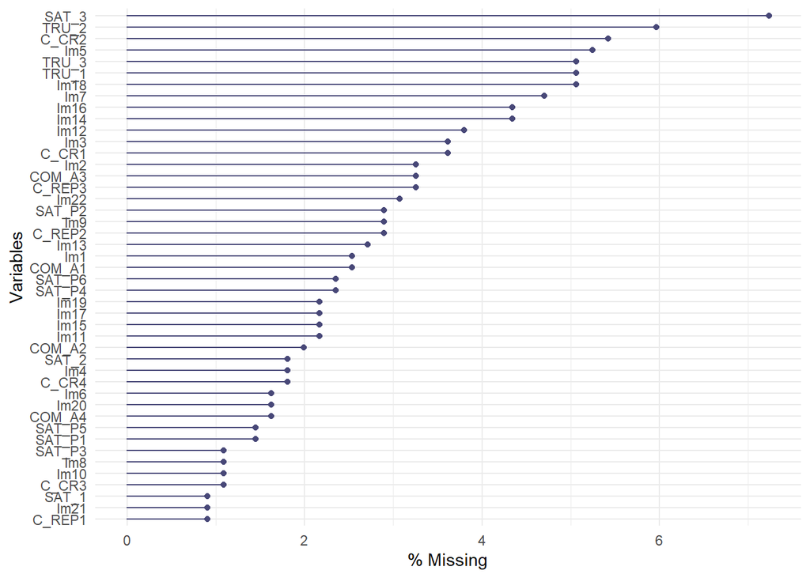

```r
gg_miss_var(data_new, show_pct = TRUE)
```

### Run a factor analysis 1. First step: Calculate the correlation matrix

```r
#select the 22 images for the factor analysis
data_new1 <- data_new[,c(1:22)]
```

#### Correlation matrix.

Checking the adequacy of the correlation matrix.

Source: http://www.sthda.com/english/wiki/correlation-matrix-a-quick-start-guide-to-analyze-format-and-visualize-a-correlation-matrix-using-r-software

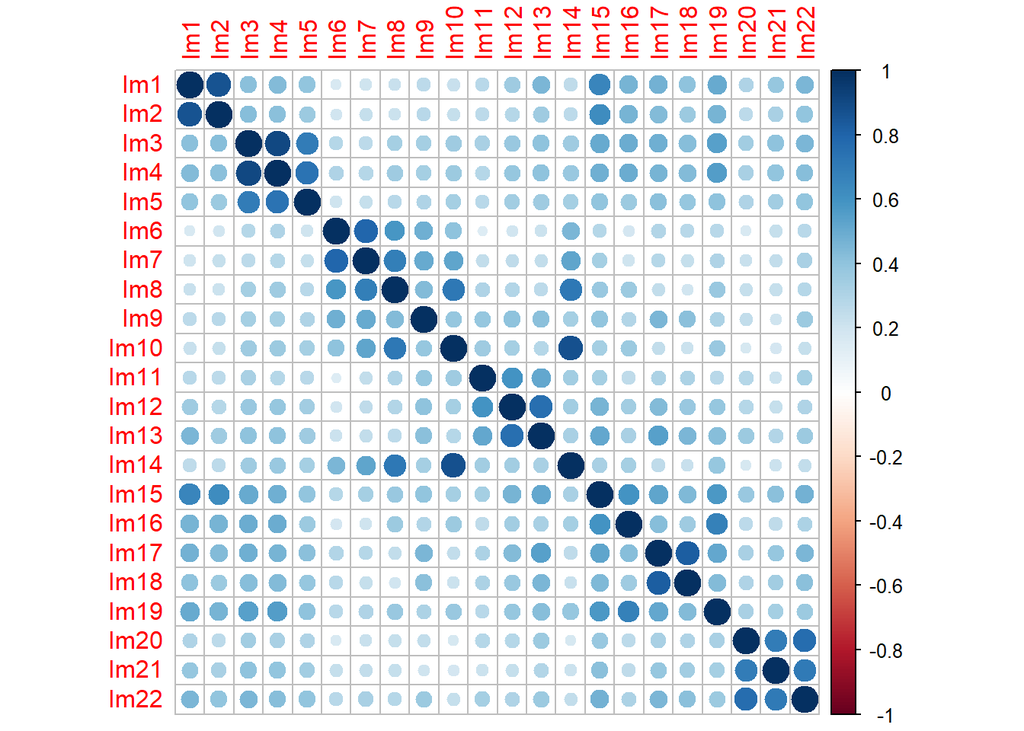

```r
raqMatrix_data = cor(data_new1, use="complete.obs") #We create a matrix.

corrplot(as.matrix(raqMatrix_data))
```

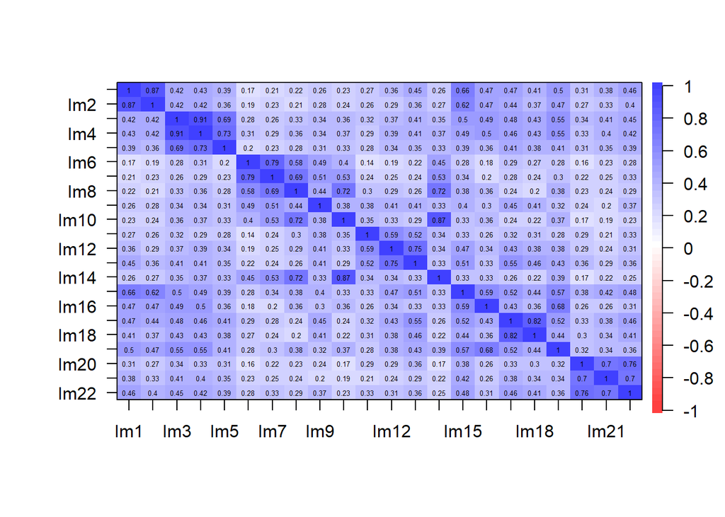

```r
cor.plot(raqMatrix_data)
```

```r
options(scipen=999)
data.corr <- rcorr(as.matrix(data_new1))
data.corr$P
```

```
##                        Im1                      Im2                      Im3
## Im1                     NA 0.0000000000000000000000 0.0000000000000000000000
## Im2  0.0000000000000000000                       NA 0.0000000000000000000000
## Im3  0.0000000000000000000 0.0000000000000000000000                       NA
## Im4  0.0000000000000000000 0.0000000000000000000000 0.0000000000000000000000
## Im5  0.0000000000000000000 0.0000000000000004440892 0.0000000000000000000000
## Im6  0.0000381300183107669 0.0000917482348783416057 0.0000000000044801939936
## Im7  0.0000035485177329875 0.0000016650741700985350 0.0000000001344113709223
## Im8  0.0000006052152961011 0.0000051527302358245208 0.0000000000000817124146
## Im9  0.0000000000241318077 0.0000000000112923004281 0.0000000000000039968029
## Im10 0.0000000016554189131 0.0000000045226666856024 0.0000000000000000000000
## Im11 0.0000000001583826403 0.0000000096352501532948 0.0000000000134323663303
## Im12 0.0000000000000000000 0.0000000000001967315200 0.0000000000000000000000
## Im13 0.0000000000000000000 0.0000000000000000000000 0.0000000000000000000000
## Im14 0.0000000000096744834 0.0000000000034847680297 0.0000000000000000000000
## Im15 0.0000000000000000000 0.0000000000000000000000 0.0000000000000000000000
## Im16 0.0000000000000000000 0.0000000000000000000000 0.0000000000000000000000
## Im17 0.0000000000000000000 0.0000000000000000000000 0.0000000000000000000000
## Im18 0.0000000000000000000 0.0000000000000000000000 0.0000000000000000000000
## Im19 0.0000000000000000000 0.0000000000000000000000 0.0000000000000000000000
## Im20 0.0000000000001234568 0.0000000001629665291603 0.0000000000000004440892
## Im21 0.0000000000000000000 0.0000000000000006661338 0.0000000000000000000000
## Im22 0.0000000000000000000 0.0000000000000000000000 0.0000000000000000000000
##                           Im4                      Im5                    Im6
## Im1  0.0000000000000000000000 0.0000000000000000000000 0.00003813001831076690
## Im2  0.0000000000000000000000 0.0000000000000004440892 0.00009174823487834161
## Im3  0.0000000000000000000000 0.0000000000000000000000 0.00000000000448019399
## Im4                        NA 0.0000000000000000000000 0.00000000000009947598
## Im5  0.0000000000000000000000                       NA 0.00000008511345983564
## Im6  0.0000000000000994759830 0.0000000851134598356396                     NA
## Im7  0.0000000000097002406108 0.0000000011821201795215 0.00000000000000000000
## Im8  0.0000000000000008881784 0.0000000000310400594117 0.00000000000000000000
## Im9  0.0000000000000082156504 0.0000000000077999828818 0.00000000000000000000
## Im10 0.0000000000000000000000 0.0000000000000208721929 0.00000000000000000000
## Im11 0.0000000000712037095951 0.0000000000928586096904 0.00080021648303008064
## Im12 0.0000000000000000000000 0.0000000000000004440892 0.00002281960618844003
## Im13 0.0000000000000000000000 0.0000000000000000000000 0.00002026616655204094
## Im14 0.0000000000000000000000 0.0000000000000000000000 0.00000000000000000000
## Im15 0.0000000000000000000000 0.0000000000000000000000 0.00000000134928113127
## Im16 0.0000000000000000000000 0.0000000000000000000000 0.00000060943216873000
```

[output cut: 129 more lines]

```
## Im8  0.0000000000040158987247
## Im9  0.0000000000000004440892
## Im10 0.0000000040369450005073
## Im11 0.0000000000015649703755
## Im12 0.0000000038854226502849
## Im13 0.0000000000000195399252
## Im14 0.0000000016798074042867
## Im15 0.0000000000000000000000
## Im16 0.0000000000000008881784
## Im17 0.0000000000000000000000
## Im18 0.0000000000000000000000
## Im19 0.0000000000000000000000
## Im20 0.0000000000000000000000
## Im21 0.0000000000000000000000
## Im22                       NA
```

We see that all correlations are statistically significant.

### Anti-image Correlation, KMO and Bartlett’s Test

Source: https://www.rdocumentation.org/packages/psych/versions/2.1.9/topics/KMO

Source: https://www.statology.org/bartletts-test-of-sphericity/

```r
KMOTEST <- KMOS(data_new1, use="complete.obs")

KMOTEST$KMO
```

```
## [1] 0.8770975
```

This seems to be a good results as it’s more than 0.8.

```r
sort(KMOTEST$MSA)
```

```
##       Im2       Im6       Im1      Im20      Im14      Im10       Im7       Im4
## 0.8224640 0.8224827 0.8244624 0.8266391 0.8267452 0.8285789 0.8448231 0.8542604
##      Im18       Im3      Im17      Im13      Im12      Im22      Im16      Im11
## 0.8550678 0.8640362 0.8644991 0.8722220 0.8789413 0.8793157 0.9092200 0.9113882
##      Im21       Im8       Im9      Im19       Im5      Im15
## 0.9149654 0.9300079 0.9380091 0.9400714 0.9546668 0.9647563
```

`Im2` and `Im6` have the lowest values but still over the threshold, so we will keep an eye out for them in further analysis.

```r
bart_spher(data_new1, use="complete.obs")
```

```
##  Bartlett's Test of Sphericity
##
## Call: bart_spher(x = data_new1, use = "complete.obs")
##
##      X2 = 6451.238
##      df = 231
## p-value < 2.22e-16
```

```r
cortest.bartlett(as.matrix(raqMatrix_data), n=100) #optional.
```

```
## $chisq
## [1] 1559.168
##
## $p.value
## [1] 0.000000000000000000000000000000000000000000000000000000000000…
##
## $df
## [1] 231
```

As the p.value < 0.05, our dataset is suitable for a data reduction technique. We could use this data frame for PCA or factor analysis. As our variables are generally correlated, we could combine them into linear combinations that are able to capture significant variance present in the data.

Bartlett‘s Test of sphericity is highly significant: The H0 that all correlations between the IVs are 0 can be rejected.

### Question 1. What are the dimensions by which Galeries Lafayette is perceived?

In this first step, we run a confirmatory factor analysis to determine the dimensions by which Galeries Lafayette is perceived by its customers. Prior to the CFA, run an exploratory factor analysis in R to get an idea of which dimensions customers perceive Galeries Lafayette

### Factor analysis using PCA method, as identified as the superior method from Case 2

Based on the information provided for the case, it is unclear how many factors/dimensions we will end up with the questionnaire’s designer.

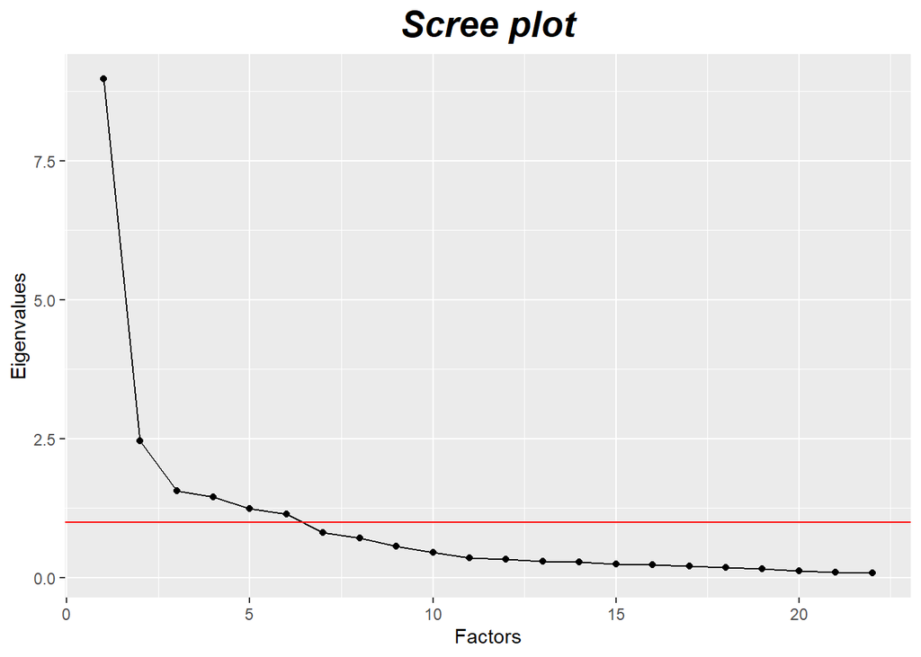

```r
r_matrix <- corr.test(data_new1, use="complete.obs")$r

screeplot <- cbind(x = seq(1:22), data.frame(y = (eigen(r_matrix)$values)))

ggplot(screeplot, aes(x = x, y = y)) +
  geom_point() +
  geom_line() +
  geom_hline(yintercept = 1, color = "red") + xlab("Factors") + ylab("Eigenvalues") +
  ggtitle("Scree plot") +
  theme(plot.title = element_text(color="black", size=20, face="bold.italic", hjust = 0.5))
```

Generally, as a rule of thumb, a factor’s Eigenvalues greater than 1 is the good benchmark, as this is when a factor shows the contribution of this factor in explaining the total variance. Based on this Scree plot, we see that the Eigenvalue of 7 factors is just below the threshold value of 1, so perhaps this might not be the best number of factors. But as a measure of assurance, we will still run a principal axis factoring with 8 factors, as well as 7 factors and 6 factors to determine the best number of factors.

Here we examine another way of looking at the Eigenvalues through tabular format and in relations with the total variance explained. Let’s see of it confirms what we previously said.

```r
eigen.v <- eigen(r_matrix)$values

var <- eigen.v/ncol(data_new1)*100

total.var <- cumsum(eigen.v/ncol(data_new1))*100

total.var.explained <- cbind(EigenValue = eigen.v, Variance = var, Total_Variance = total.var)

round(total.var.explained, 5)
```

```
##       EigenValue Variance Total_Variance
##  [1,]    8.97759 40.80721       40.80721
##  [2,]    2.46726 11.21484       52.02205
##  [3,]    1.56196  7.09981       59.12186
##  [4,]    1.45684  6.62199       65.74386
##  [5,]    1.24785  5.67205       71.41591
##  [6,]    1.14734  5.21517       76.63108
##  [7,]    0.81010  3.68227       80.31335
##  [8,]    0.71161  3.23460       83.54795
##  [9,]    0.56786  2.58116       86.12911
## [10,]    0.45684  2.07656       88.20568
## [11,]    0.36140  1.64273       89.84840
## [12,]    0.33235  1.51067       91.35907
## [13,]    0.29500  1.34090       92.69997
## [14,]    0.28352  1.28871       93.98868
## [15,]    0.24936  1.13347       95.12216
## [16,]    0.22811  1.03687       96.15902
## [17,]    0.20225  0.91933       97.07835
## [18,]    0.18624  0.84655       97.92490
## [19,]    0.15737  0.71533       98.64023
## [20,]    0.11624  0.52835       99.16858
## [21,]    0.10167  0.46215       99.63073
## [22,]    0.08124  0.36927      100.00000
```

### Factor Analysis for 8 factors

```r
pa_8 <- principal(data_new1, nfactors = 8, rotate = 'varimax')
print(pa_8$loadings, cutoff = 0.3, sort = TRUE)
```

```
##
## Loadings:
##      RC1    RC3    RC2    RC4    RC7    RC5    RC8    RC6
## Im3   0.839
## Im4   0.859
## Im5   0.808
## Im20         0.869
## Im21         0.828
## Im22         0.810
## Im6                 0.867
## Im7                 0.845         0.324
## Im9                 0.630  0.391
## Im11                       0.743
## Im12                       0.837
## Im13                       0.759
## Im8                 0.552         0.617
## Im10                              0.866
## Im14                              0.869
## Im1                                      0.874
## Im2                                      0.895
## Im15                                     0.523  0.457
## Im16                                            0.820
## Im19                                            0.717
## Im17                                                   0.801
## Im18                                                   0.859
##
##                 RC1   RC3   RC2   RC4   RC7   RC5   RC8   RC6
## SS loadings    2.63 2.527 2.505 2.450 2.262 2.247 1.789 1.786
## Proportion Var 0.12 0.115 0.114 0.111 0.103 0.102 0.081 0.081
## Cumulative Var 0.12 0.234 0.348 0.460 0.562 0.665 0.746 0.827
```

```r
sort(pa_8[["communality"]])
```

```
##       Im9      Im11      Im15       Im8      Im13      Im21      Im19       Im5
## 0.6474160 0.6561563 0.7231830 0.7608028 0.7640833 0.7742910 0.7746297 0.7833496
##      Im12      Im22       Im6      Im20      Im16       Im7       Im3      Im10
## 0.8146265 0.8185995 0.8299427 0.8391191 0.8494787 0.8611256 0.8886227 0.9039634
##      Im17      Im18      Im14       Im4       Im2       Im1
## 0.9072324 0.9153208 0.9160462 0.9161525 0.9228365 0.9281304
```

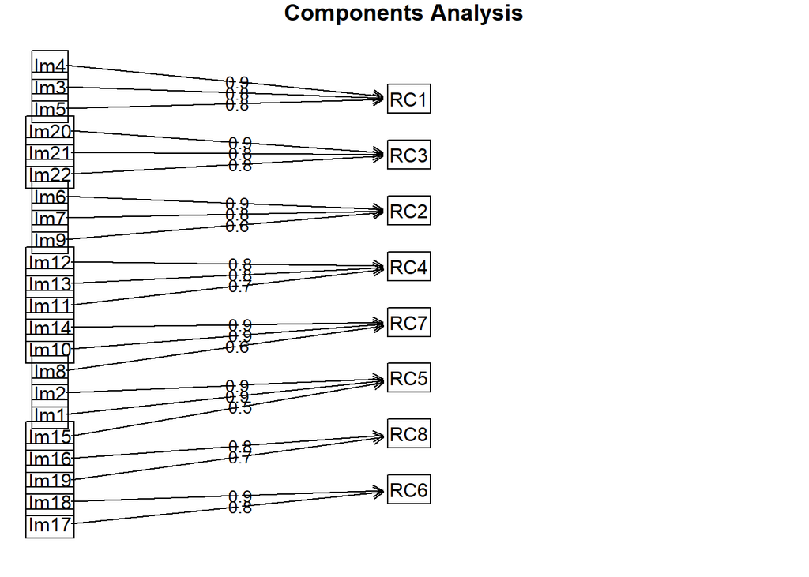

```r
fa.diagram(pa_8)
```

We see that Im9, Im11 and Im15 have the lowest communalities of all. Meanwhile, Im8, Im9 and Im15 have low loadings, so we should keep an eye out for them. Furthermore, while Im8 is loaded with Im10 and Im14, which are all in the theme of food, Im8 is slightly different in that it’s about French traditional cuisine while the other 2 images are about gourmet food. Not all French traditional cuisines are gourmet.

Im9 is loaded together with Im6 and Im7. They are indeed around French themes, the country itself, the French art of living and French fashion. We could say that French fashion is slightly more specific than France the country and French art of living. Im15 is loaded with Im1 and Im2. While the first two images are about assortment qualities, Im15 is also about the quality of the brand selection in the sense that it’s professional. It’s also ambivalent that it’s loaded also in Factor 8 about the professionalism of the Galleries. So this might be slightly out of place. We can examine if when we reduce a factor, Im15 would be loaded more accurately.

### For 7 factors

```r
pa_7 <- principal(data_new1, nfactors = 7, rotate = 'varimax')
print(pa_7$loadings, cutoff = 0.3, sort = TRUE)
```

```
##
## Loadings:
##      RC5    RC1    RC2    RC3    RC7    RC4    RC6
## Im1   0.879
## Im2   0.895
## Im15  0.637
## Im3          0.852
## Im4          0.871
## Im5          0.800
## Im6                 0.854
## Im7                 0.846         0.309
## Im9                 0.607                0.375
## Im20                       0.867
## Im21                       0.828
## Im22                       0.809
## Im8                 0.558         0.637
## Im10                0.310         0.820
## Im14                0.324         0.785
## Im11                                     0.742
## Im12                                     0.826
## Im13                                     0.754
## Im17                                            0.791
## Im18                                            0.818
## Im16  0.456                       0.478         0.363
## Im19  0.412  0.343                0.443         0.398
##
##                  RC5   RC1   RC2   RC3   RC7   RC4   RC6
## SS loadings    2.774 2.745 2.548 2.509 2.479 2.409 2.012
## Proportion Var 0.126 0.125 0.116 0.114 0.113 0.110 0.091
## Cumulative Var 0.126 0.251 0.367 0.481 0.593 0.703 0.794
```

```r
sort(pa_7[["communality"]])
```

```
##       Im9      Im11      Im19      Im16      Im15       Im8       Im5      Im13
## 0.6237029 0.6537032 0.6694975 0.6722257 0.6949375 0.7604627 0.7622855 0.7630561
##      Im21      Im12       Im6      Im22      Im14      Im20      Im10      Im18
## 0.7735736 0.8055122 0.8122980 0.8185976 0.8199069 0.8353676 0.8487007 0.8507461
##       Im7      Im17       Im2       Im3       Im1       Im4
## 0.8519518 0.8756503 0.8837405 0.8886157 0.8948880 0.9161483
```

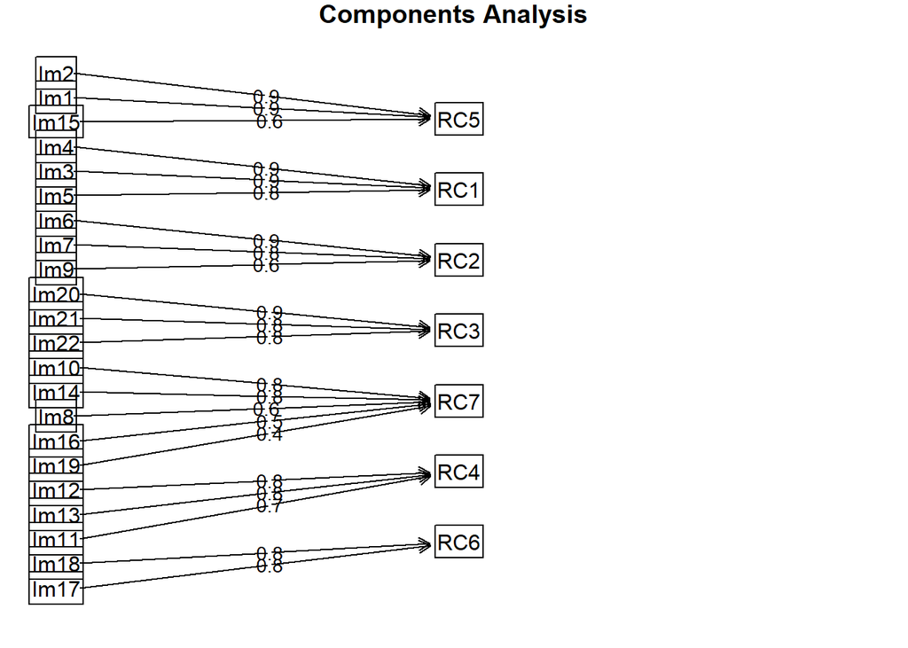

```r
fa.diagram(pa_7)
```

The spotted suspect Im 15, Im9 and Im8 keep having somewhat weak loadings. Im15 is still loaded with Im1 and Im2 and stopped being loaded with Im16 and Im19.

With 7 factors, we saw that Im16 and Im19 previously loading well in the 8th factor now spread across Factor 5, Factor 6 and Factor 7 with very weak loadings. The strongest loadings are with Factor 7 but the content of these Images don’t go together with other Images in the same factor (about cuisines).

Perhaps we should have 8 factors after all. But to be sure, let’s try with 6 factors, just as a safety measure for our analysis.

```r
pa_6 <- principal(data_new1, nfactors = 6, rotate = 'varimax')
print(pa_6$loadings, cutoff = 0.3, sort = TRUE)
```

```
##
## Loadings:
##      RC2    RC5    RC1    RC3    RC4    RC6
## Im6   0.746                              0.440
## Im7   0.827                              0.325
## Im8   0.831
## Im10  0.765                       0.304
## Im14  0.752                       0.301
## Im1          0.857
## Im2          0.870
## Im15         0.676
## Im16         0.603  0.382
## Im19         0.551  0.430
## Im3                 0.851
## Im4                 0.866
## Im5                 0.778
## Im20                       0.865
## Im21                       0.826
## Im22                       0.810
## Im11                              0.748
## Im12                              0.820
## Im13                              0.739
## Im17         0.377                       0.654
## Im18                                     0.693
## Im9   0.479                       0.310  0.493
##
##                  RC2   RC5   RC1   RC3   RC4   RC6
## SS loadings    3.652 3.308 2.934 2.498 2.448 1.849
## Proportion Var 0.166 0.150 0.133 0.114 0.111 0.084
## Cumulative Var 0.166 0.316 0.450 0.563 0.675 0.759
```

```r
sort(pa_6[["communality"]])
```

```
##      Im16      Im19       Im9      Im11      Im15       Im5      Im18      Im13
## 0.5821631 0.5992829 0.6001602 0.6462519 0.6923790 0.7214710 0.7339548 0.7560843
##       Im8      Im21      Im17       Im6      Im14      Im12      Im10       Im7
## 0.7566046 0.7735618 0.7740562 0.7772842 0.7894080 0.7972213 0.7997784 0.8136260
##      Im22       Im2      Im20       Im1       Im3       Im4
## 0.8183083 0.8192640 0.8333213 0.8344941 0.8744046 0.8956809
```

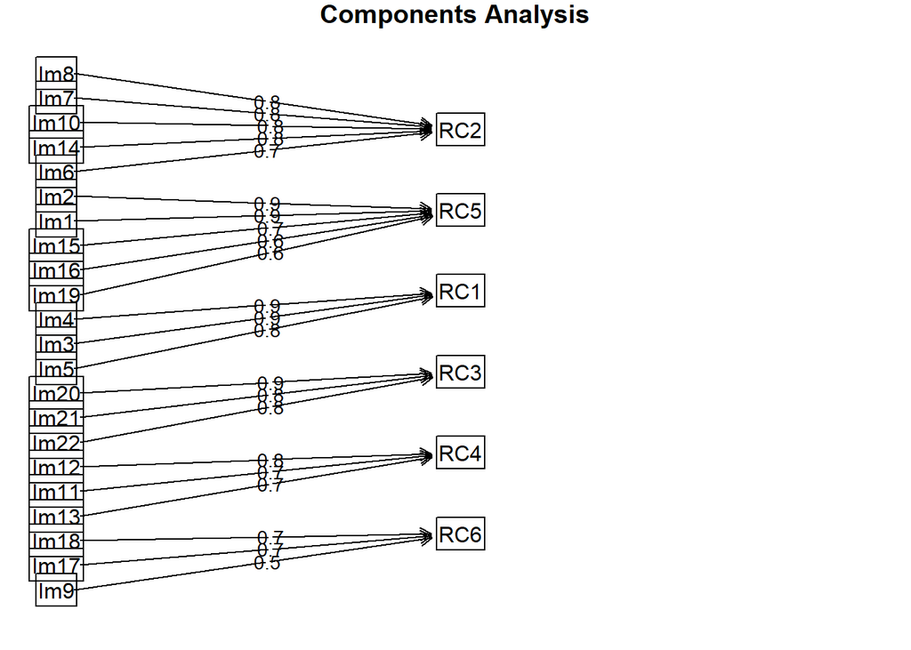

```r
fa.diagram(pa_6)
```

We see that Im8 seems to have good loadings here in Factor 2. However when we look at the Image descriptions, the Images seem a rather out of place when Im8 talks about cuisine which goes with Im10 and Im14, but Im7 and Im6 talk about France-related things in general and not necessary relating to food.

Im9 (French fashion) still has low loading but now loaded in Factor 6 with Im18 and Im17 which talk about being trendy and hip in general. There are some relations, but I wouldn’t say the link is very obvious.

Im15 now loaded with Im1, Im2, Im16 and Im19. While Im15 has closer ties with Im16 and Im19 (in terms of the professional aspect), it doesn’t really link with Im1 and Im2 (in terms of assortment). So I would say this Factor doesn’t really make sense.

So having 6 factors might be a stretch, forcing certain Images to be in the same factors.

With these in mind, I would say that 8 factors make the most sense as they seem to represent different separate concepts. We could try rerunning without the images that are causing issues (Im8, 9 and 15).

```r
data_new2 <- data_new1[,-c(8,9,15)] #New dataset.
```

### For 8 factors with new data set

```r
pa_8_new <- principal(data_new2, nfactors = 8, rotate = 'varimax')
print(pa_8_new$loadings, cutoff = 0.3, sort = TRUE)
```

```
##
## Loadings:
##      RC1    RC3    RC4    RC5    RC8    RC2    RC6    RC7
## Im3   0.845
## Im4   0.863
## Im5   0.812
## Im20         0.872
## Im21         0.829
## Im22         0.816
## Im11                0.738
## Im12                0.855
## Im13                0.777
## Im1                        0.872
## Im2                        0.896
## Im10                              0.883
## Im14                              0.870
## Im6                                      0.912
## Im7                                      0.864
## Im17                                            0.813
## Im18                                            0.865
## Im16                                                   0.823
## Im19                                                   0.743
##
##                  RC1   RC3   RC4   RC5   RC8   RC2   RC6   RC7
## SS loadings    2.614 2.498 2.279 1.900 1.848 1.830 1.777 1.581
## Proportion Var 0.138 0.131 0.120 0.100 0.097 0.096 0.094 0.083
## Cumulative Var 0.138 0.269 0.389 0.489 0.586 0.683 0.776 0.859
```

```r
sort(pa_8_new[["communality"]])
```

```
##      Im11      Im21       Im5      Im13      Im19      Im22      Im12      Im20
## 0.6556189 0.7704398 0.7846701 0.7858609 0.8092869 0.8179530 0.8371130 0.8398643
##      Im16       Im7       Im3       Im6      Im17      Im18       Im4      Im14
## 0.8545329 0.8886258 0.8888672 0.9068159 0.9096278 0.9158074 0.9163427 0.9308581
##      Im10       Im2       Im1
## 0.9348638 0.9399334 0.9408195
```

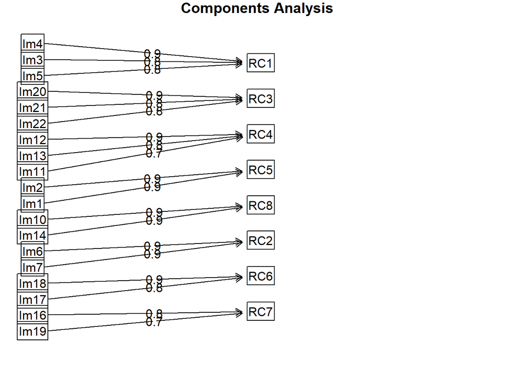

```r
fa.diagram(pa_8_new)
```

### For 7 factors new data set

```r
pa_7_new <- principal(data_new2, nfactors = 7, rotate = 'varimax')
print(pa_7_new$loadings, cutoff = 0.3, sort = TRUE)
```

```
##
## Loadings:
##      RC1    RC3    RC4    RC2    RC5    RC7    RC6
## Im3   0.855
## Im4   0.874
## Im5   0.805
## Im20         0.872
## Im21         0.829
## Im22         0.816
## Im11                0.747
## Im12                0.837
## Im13                0.762                       0.309
## Im6                        0.881
## Im7                        0.878
## Im1                               0.878
## Im2                               0.901
## Im10                       0.460         0.729
## Im14                0.305  0.492         0.672
## Im16                              0.315  0.636  0.335
## Im19  0.332                              0.567  0.381
## Im17                                            0.801
## Im18                                            0.825
##
##                  RC1   RC3   RC4   RC2   RC5   RC7   RC6
## SS loadings    2.706 2.500 2.327 2.158 2.023 1.965 1.959
## Proportion Var 0.142 0.132 0.122 0.114 0.106 0.103 0.103
## Cumulative Var 0.142 0.274 0.397 0.510 0.617 0.720 0.823
```

```r
sort(pa_7_new[["communality"]])
```

```
##      Im11      Im19      Im16       Im5      Im21      Im13      Im12      Im22
## 0.6501950 0.7009264 0.7279135 0.7669750 0.7702679 0.7773783 0.8138221 0.8178015
##      Im14      Im20       Im6      Im18      Im10       Im7      Im17       Im3
## 0.8252878 0.8383189 0.8465872 0.8506240 0.8529918 0.8535771 0.8766603 0.8888124
##       Im4       Im2       Im1
## 0.9163143 0.9303543 0.9345602
```

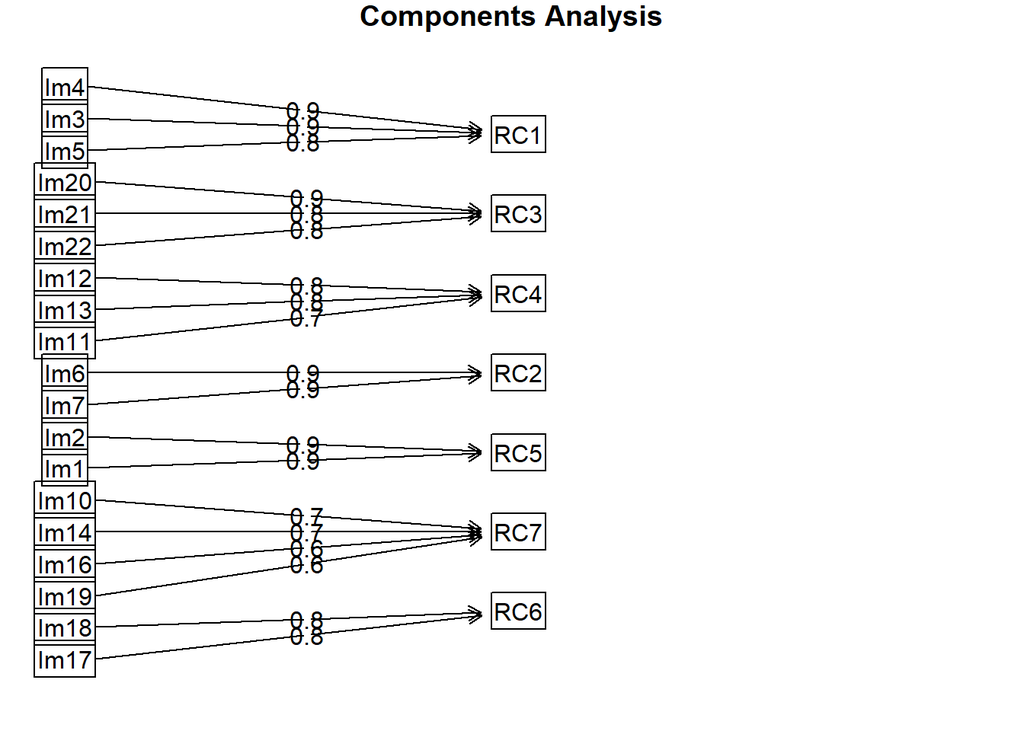

```r
fa.diagram(pa_7_new)
```

### For 6 factors new data set

```r
pa_6_new <- principal(data_new2, nfactors = 6, rotate = 'varimax')
print(pa_6_new$loadings, cutoff = 0.3, sort = TRUE)
```

```
##
## Loadings:
##      RC1    RC2    RC5    RC3    RC4    RC6
## Im3   0.862
## Im4   0.876
## Im5   0.784
## Im6          0.816                       0.342
## Im7          0.855
## Im10         0.725                0.350
## Im14         0.727                0.352
## Im1                 0.853
## Im2                 0.878
## Im16  0.418         0.577
## Im19  0.446         0.525
## Im20                       0.868
## Im21                       0.828
## Im22                       0.818
## Im11                              0.755
## Im12                              0.831
## Im13                              0.747  0.329
## Im17                0.325                0.713
## Im18                                     0.753
##
##                  RC1   RC2   RC5   RC3   RC4   RC6
## SS loadings    2.960 2.709 2.621 2.485 2.413 1.678
## Proportion Var 0.156 0.143 0.138 0.131 0.127 0.088
## Cumulative Var 0.156 0.298 0.436 0.567 0.694 0.782
```

```r
sort(pa_6_new[["communality"]])
```

```
##      Im16      Im19      Im11       Im5      Im13      Im21      Im18      Im12
## 0.5718440 0.5993845 0.6464888 0.7221141 0.7627000 0.7702616 0.7948635 0.8025569
##      Im14      Im10       Im6       Im7      Im22      Im17      Im20       Im2
## 0.8059612 0.8073022 0.8082927 0.8133691 0.8177575 0.8235263 0.8336425 0.8522606
##       Im1       Im3       Im4
## 0.8567977 0.8774955 0.8987651
```

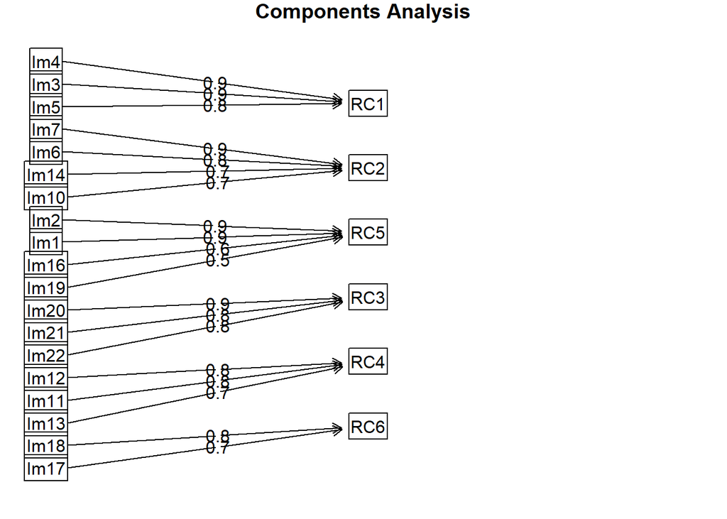

```r
fa.diagram(pa_6_new)
```

Based on these reruns of the PCA models with different numbers of factors using the new data set, we can conclude that the model with 8 factors is the most optimal. This model has clean high loadings and no cross-loadings. The moment we reduce the number of factors, images are being forced with new factors that don’t really make sense conceptually and they also have weaker cross-loadings.

We ended up with 8 dimensions:

Factor 1: Im3, Im4 and Im5. It could be associated to decoration. Factor 2: Im6 and Im7. It could be associated to France country. Factor 3: Im20, Im21 and Im22. It could be associated to relaxation atmosphere. Factor 4: Im11, Im12 and Im13. It could be associated to luxury. Factor 5: Im1 and Im2. It could be associated to assortment/diversity. Factor 6: Im17 and Im18. It could be associated to trend. Factor 7: Im16 and Im19. It could be associated to professionalism. Factor 8: Im10 and Im14. It could be associated to gourmet food.

### Confirmatory Factor Analysis

As seen in the seminar of the 7th April, we create the model as follows:

```r
model<-"
Decoration=~Im3+Im4+Im5
France=~Im6+Im7
Relaxation=~Im20+Im21+Im22
Luxury=~Im11+Im12+Im13
Assortment=~Im1+Im2
Trend=~Im17+Im18
Professionalism=~Im16+Im19
Gourmet=~Im10+Im14
"

fit <- cfa(model, data=data_new, missing="ML")
Sum_fit <- summary(fit, fit.measures=TRUE,standardized=TRUE)
```

```
## lavaan 0.6-11 ended normally after 108 iterations
##
##   Estimator                                         ML
##   Optimization method                           NLMINB
##   Number of model parameters                        85
##
##   Number of observations                           553
##   Number of missing patterns                        79
##
## Model Test User Model:
##
##   Test statistic                               259.047
##   Degrees of freedom                               124
##   P-value (Chi-square)                           0.000
##
## Model Test Baseline Model:
##
##   Test statistic                              7474.765
##   Degrees of freedom                               171
##   P-value                                        0.000
##
## User Model versus Baseline Model:
##
##   Comparative Fit Index (CFI)                    0.982
##   Tucker-Lewis Index (TLI)                       0.975
##
## Loglikelihood and Information Criteria:
##
##   Loglikelihood user model (H0)             -12973.111
##   Loglikelihood unrestricted model (H1)     -12843.588
##
##   Akaike (AIC)                               26116.223
##   Bayesian (BIC)                             26483.028
##   Sample-size adjusted Bayesian (BIC)        26213.200
##
## Root Mean Square Error of Approximation:
##
##   RMSEA                                          0.044
##   90 Percent confidence interval - lower         0.037
##   90 Percent confidence interval - upper         0.052
```

[output cut: 124 more lines]

```
##    .Im2               0.317    0.044    7.233    0.000    0.317    0.192
##    .Im17              0.095    0.045    2.112    0.035    0.095    0.062
##    .Im18              0.521    0.055    9.540    0.000    0.521    0.267
##    .Im16              0.599    0.052   11.498    0.000    0.599    0.414
##    .Im19              0.338    0.045    7.457    0.000    0.338    0.267
##    .Im10              0.114    0.019    5.961    0.000    0.114    0.148
##    .Im14              0.070    0.019    3.680    0.000    0.070    0.093
##     Decoration        1.528    0.107   14.326    0.000    1.000    1.000
##     France            0.952    0.095   10.058    0.000    1.000    1.000
##     Relaxation        1.599    0.138   11.623    0.000    1.000    1.000
##     Luxury            0.494    0.067    7.361    0.000    1.000    1.000
##     Assortment        1.704    0.118   14.388    0.000    1.000    1.000
##     Trend             1.451    0.104   13.988    0.000    1.000    1.000
##     Professionalsm    0.849    0.088    9.638    0.000    1.000    1.000
##     Gourmet           0.659    0.049   13.328    0.000    1.000    1.000
```

Let’s have a look at some coefficients/values to estimate the global fit measures.

RMSEA lower or equal to 0.05, it is a good fit. (Hu & Bentler (1999) suggest a cut off value of 0.06 before one can conclude that there is a good fit between model and data.) Here, the RMSEA is 0.044 so we have a very good fit.

As mentioned in the lecture, ratio Chi2-value/df should be below 5 for samples up to 1000. Here, we note that we have 553 observation though. In our case, the Chi-square test: 259.047/124 = 2.089089, which is less than 5 so the fit of the model is good.

Regarding the User Model versus Baseline Model, if the Comparative Fit Index (CFI) is > 0.95, we accept the model. Here, the CFI is equal to 0.982, so we can accept our model.

Our three global fit measures are very satisfactory!

```r
Sum_fit$FIT[c("chisq","df","rmsea","cfi")]
```

```
##        chisq           df        rmsea          cfi
## 259.04749819 124.00000000   0.04437822   0.98150988
```

Regarding the Latent Variables part, the loading of all indicators (0.615 for Im11 and 0.760 for Im5 are the smallest ones) are very good. Almost each loading is more than 0.7 which means at least 50% of the indicator’s variance is accounted for by the underlying construct.

```r
CronDeco=cronbach(subset(data_new2, select = c(Im3:Im5)))
CronDeco
```

```
## $sample.size
## [1] 508
##
## $number.of.items
## [1] 3
##
## $alpha
## [1] 0.9151505
```

```r
CronFrance=cronbach(subset(data_new2, select = c(Im6:Im7)))
CronFrance
```

```
## $sample.size
## [1] 520
##
## $number.of.items
## [1] 2
##
## $alpha
## [1] 0.8758912
```

```r
CronRela=cronbach(subset(data_new2, select = c(Im20:Im22)))
CronRela
```

```
## $sample.size
## [1] 525
##
## $number.of.items
## [1] 3
##
## $alpha
## [1] 0.8749604
```

```r
CronLux=cronbach(subset(data_new2, select = c(Im11:Im13)))
CronLux
```

```
## $sample.size
## [1] 520
##
## $number.of.items
## [1] 3
##
## $alpha
## [1] 0.8127499
```

```r
CronAsso=cronbach(subset(data_new2, select = c(Im1:Im2)))
CronAsso
```

```
## $sample.size
## [1] 525
##
## $number.of.items
## [1] 2
##
## $alpha
## [1] 0.9372013
```

```r
CronTrend=cronbach(subset(data_new2, select = c(Im17:Im18)))
CronTrend
```

```
## $sample.size
## [1] 521
##
## $number.of.items
## [1] 2
##
## $alpha
## [1] 0.9039139
```

```r
CronPro=cronbach(subset(data_new2, select = c(Im16,Im19)))
CronPro
```

```
## $sample.size
## [1] 520
##
## $number.of.items
## [1] 2
##
## $alpha
## [1] 0.7940545
```

```r
CronGourmet=cronbach(subset(data_new2, select = c(Im10,Im14)))
CronGourmet
```

```
## $sample.size
## [1] 525
##
## $number.of.items
## [1] 2
##
## $alpha
## [1] 0.9334071
```

All constructs have Cronbach’s Alpha more than 0.79 (Cronbach ́s a > 0.7, i.e. is good measurement) which indicate having high internal consistency reliability. we just look at modification indices to be sure. They all seem pretty normal and low. If anything Trend and Im13 (as part of Luxury), as well as Im11 and Im13 (both as part of Luxury) seem to be more more correlated and share some higher variance than the rest.

```r
modificationindices(fit) %>%filter(mi>10)
```

```
##           lhs op  rhs     mi    epc sepc.lv sepc.all sepc.nox
## 1  Relaxation =~ Im12 10.952 -0.115  -0.145   -0.127   -0.127
## 2  Assortment =~ Im20 14.777 -0.151  -0.197   -0.132   -0.132
## 3  Assortment =~ Im12 10.663 -0.111  -0.145   -0.127   -0.127
## 4  Assortment =~ Im13 13.970  0.133   0.174    0.144    0.144
## 5       Trend =~ Im12 17.245 -0.179  -0.216   -0.190   -0.190
## 6       Trend =~ Im13 23.832  0.220   0.265    0.220    0.220
## 7     Gourmet =~ Im11 12.742  0.215   0.174    0.152    0.152
## 8        Im20 ~~ Im21 11.455  0.228   0.228    0.335    0.335
## 9        Im21 ~~ Im22 15.139 -0.285  -0.285   -0.455   -0.455
## 10       Im11 ~~ Im12 13.307  0.145   0.145    0.288    0.288
## 11       Im11 ~~ Im13 21.323 -0.191  -0.191   -0.338   -0.338
## 12       Im13 ~~  Im1 10.707  0.068   0.068    0.409    0.409
```

```r
std_fit=inspect(fit, "std")
std_fit$psi
```

```
##                 Decrtn France Relxtn Luxury Assrtm Trend Prfssn Gourmt
## Decoration      1.000
## France          0.334  1.000
## Relaxation      0.467  0.333  1.000
## Luxury          0.471  0.306  0.418  1.000
## Assortment      0.441  0.225  0.448  0.478  1.000
## Trend           0.517  0.322  0.516  0.566  0.519  1.000
## Professionalism 0.653  0.366  0.478  0.529  0.597  0.601 1.000
## Gourmet         0.416  0.585  0.295  0.452  0.309  0.325 0.498  1.000
```

The correlation matrix shows that the constructs are relatively distinct. If anything, Professionalism tends to show a bit more similarities with Decoration and Trend, but these are not too high and we could still choose to keep them.

```r
parameterestimates(fit, boot.ci.type = "bca.simple", standardized = TRUE)%>% kable()
```

| lhs | op | rhs | est | se | z | pvalue | ci.lower | ci.upper | std.lv | std.all | std.nox |
| --- | --- | --- | --- | --- | --- | --- | --- | --- | --- | --- | --- |
| Decoration | =~ | Im3 | 1.0000000 | 0.0000000 | NA | NA | 1.0000000 | 1.0000000 | 1.2359658 | 0.9367725 | 0.9367725 |
| Decoration | =~ | Im4 | 1.0562180 | 0.0247262 | 42.716507 | 0.0000000 | 1.0077555 | 1.1046805 | 1.3054493 | 0.9694446 | 0.9694446 |
| Decoration | =~ | Im5 | 0.8178297 | 0.0343413 | 23.814726 | 0.0000000 | 0.7505219 | 0.8851375 | 1.0108096 | 0.7601409 | 0.7601409 |
| France | =~ | Im6 | 1.0000000 | 0.0000000 | NA | NA | 1.0000000 | 1.0000000 | 0.9754581 | 0.8131641 | 0.8131641 |
| France | =~ | Im7 | 1.1842987 | 0.0706189 | 16.770272 | 0.0000000 | 1.0458882 | 1.3227093 | 1.1552338 | 0.9550802 | 0.9550802 |
| Relaxation | =~ | Im20 | 1.0000000 | 0.0000000 | NA | NA | 1.0000000 | 1.0000000 | 1.2646012 | 0.8453894 | 0.8453894 |
| Relaxation | =~ | Im21 | 0.8489173 | 0.0407673 | 20.823498 | 0.0000000 | 0.7690149 | 0.9288197 | 1.0735418 | 0.7834326 | 0.7834326 |
| Relaxation | =~ | Im22 | 1.0598941 | 0.0468850 | 22.606244 | 0.0000000 | 0.9680012 | 1.1517871 | 1.3403434 | 0.8767072 | 0.8767072 |
| Luxury | =~ | Im11 | 1.0000000 | 0.0000000 | NA | NA | 1.0000000 | 1.0000000 | 0.7029591 | 0.6145745 | 0.6145745 |
| Luxury | =~ | Im12 | 1.4102147 | 0.0937251 | 15.046293 | 0.0000000 | 1.2265169 | 1.5939124 | 0.9913233 | 0.8719185 | 0.8719185 |
| Luxury | =~ | Im13 | 1.4646568 | 0.1048551 | 13.968385 | 0.0000000 | 1.2591445 | 1.6701691 | 1.0295939 | 0.8549781 | 0.8549781 |
| Assortment | =~ | Im1 | 1.0000000 | 0.0000000 | NA | NA | 1.0000000 | 1.0000000 | 1.3052703 | 0.9800185 | 0.9800185 |
| Assortment | =~ | Im2 | 0.8851715 | 0.0327323 | 27.042790 | 0.0000000 | 0.8210175 | 0.9493256 | 1.1553881 | 0.8989149 | 0.8989149 |
| Trend | =~ | Im17 | 1.0000000 | 0.0000000 | NA | NA | 1.0000000 | 1.0000000 | 1.2044990 | 0.9687197 | 0.9687197 |
| Trend | =~ | Im18 | 0.9938479 | 0.0411645 | 24.143332 | 0.0000000 | 0.9131670 | 1.0745288 | 1.1970889 | 0.8563449 | 0.8563449 |
| Professionalism | =~ | Im16 | 1.0000000 | 0.0000000 | NA | NA | 1.0000000 | 1.0000000 | 0.9213055 | 0.7658145 | 0.7658145 |
| Professionalism | =~ | Im19 | 1.0455261 | 0.0608933 | 17.169818 | 0.0000000 | 0.9261775 | 1.1648747 | 0.9632489 | 0.8562871 | 0.8562871 |
| Gourmet | =~ | Im10 | 1.0000000 | 0.0000000 | NA | NA | 1.0000000 | 1.0000000 | 0.8117870 | 0.9231435 | 0.9231435 |
| Gourmet | =~ | Im14 | 1.0152003 | 0.0356474 | 28.478938 | 0.0000000 | 0.9453327 | 1.0850680 | 0.8241264 | 0.9523888 | 0.9523888 |
| Im3 | ~~ | Im3 | 0.2131714 | 0.0243487 | 8.754927 | 0.0000000 | 0.1654488 | 0.2608940 | 0.2131714 | 0.1224572 | 0.1224572 |
| Im4 | ~~ | Im4 | 0.1091205 | 0.0240777 | 4.532010 | 0.0000058 | 0.0619290 | 0.1563120 | 0.1091205 | 0.0601772 | 0.0601772 |
| Im5 | ~~ | Im5 | 0.7465417 | 0.0490607 | 15.216710 | 0.0000000 | 0.6503846 | 0.8426988 | 0.7465417 | 0.4221858 | 0.4221858 |
| Im6 | ~~ | Im6 | 0.4874818 | 0.0561797 | 8.677186 | 0.0000000 | 0.3773716 | 0.5975920 | 0.4874818 | 0.3387642 | 0.3387642 |
| Im7 | ~~ | Im7 | 0.1284880 | 0.0665898 | 1.929545 | 0.0536632 | -0.0020256 | 0.2590016 | 0.1284880 | 0.0878218 | 0.0878218 |
| Im20 | ~~ | Im20 | 0.6384411 | 0.0610889 | 10.451008 | 0.0000000 | 0.5187089 | 0.7581732 | 0.6384411 | 0.2853167 | 0.2853167 |
| Im21 | ~~ | Im21 | 0.7252444 | 0.0572326 | 12.671881 | 0.0000000 | 0.6130706 | 0.8374182 | 0.7252444 | 0.3862333 | 0.3862333 |
| Im22 | ~~ | Im22 | 0.5408258 | 0.0633323 | 8.539491 | 0.0000000 | 0.4166967 | 0.6649549 | 0.5408258 | 0.2313845 | 0.2313845 |
| Im11 | ~~ | Im11 | 0.8141600 | 0.0550047 | 14.801636 | 0.0000000 | 0.7063527 | 0.9219672 | 0.8141600 | 0.6222982 | 0.6222982 |
| Im12 | ~~ | Im12 | 0.3099219 | 0.0395081 | 7.844525 | 0.0000000 | 0.2324876 | 0.3873563 | 0.3099219 | 0.2397582 | 0.2397582 |
| Im13 | ~~ | Im13 | 0.3901165 | 0.0445070 | 8.765281 | 0.0000000 | 0.3028843 | 0.4773486 | 0.3901165 | 0.2690124 | 0.2690124 |

[output cut: 71 more lines]

```r
#Local Fit

std.loadings<- inspect(fit, what="std")$lambda
check=std.loadings
check[check>0] <- 1
std.loadings[std.loadings==0] <- NA
std.loadings2 <- std.loadings^2
std.theta<- inspect(fit, what="std")$theta

#Individual item Reliability
IIR=std.loadings2/(colSums(std.theta)+std.loadings2)
IIR
```

```
##      Decrtn France Relxtn Luxury Assrtm Trend Prfssn Gourmt
## Im3   0.878     NA     NA     NA     NA    NA     NA     NA
## Im4   0.940     NA     NA     NA     NA    NA     NA     NA
## Im5   0.578     NA     NA     NA     NA    NA     NA     NA
## Im6      NA  0.661     NA     NA     NA    NA     NA     NA
## Im7      NA  0.912     NA     NA     NA    NA     NA     NA
## Im20     NA     NA  0.715     NA     NA    NA     NA     NA
## Im21     NA     NA  0.614     NA     NA    NA     NA     NA
## Im22     NA     NA  0.769     NA     NA    NA     NA     NA
## Im11     NA     NA     NA  0.378     NA    NA     NA     NA
## Im12     NA     NA     NA  0.760     NA    NA     NA     NA
## Im13     NA     NA     NA  0.731     NA    NA     NA     NA
## Im1      NA     NA     NA     NA  0.960    NA     NA     NA
## Im2      NA     NA     NA     NA  0.808    NA     NA     NA
## Im17     NA     NA     NA     NA     NA 0.938     NA     NA
## Im18     NA     NA     NA     NA     NA 0.733     NA     NA
## Im16     NA     NA     NA     NA     NA    NA  0.586     NA
## Im19     NA     NA     NA     NA     NA    NA  0.733     NA
## Im10     NA     NA     NA     NA     NA    NA     NA  0.852
## Im14     NA     NA     NA     NA     NA    NA     NA  0.907
```

True score variance of the item divided by total variance and should be larger than 0.4. Except for Im11, all the coefficients are larger than 0.4!

```r
#Composite/Construct Reliability
sum.std.loadings<-colSums(std.loadings, na.rm=TRUE)^2
sum.std.theta<-rowSums(std.theta)
sum.std.theta=check*sum.std.theta
CR=sum.std.loadings/(sum.std.loadings+colSums(sum.std.theta))
CR
```

```
##      Decoration          France      Relaxation          Luxury      Assortment
##       0.9215974       0.8799456       0.8742538       0.8289772       0.9384579
##           Trend Professionalism         Gourmet
##       0.9102910       0.7945651       0.9359401
```

Construct reliabilities are above 0.6 for all constructs (even higher than 0.79 here)!

```r
#Average Variance Extracted
std.loadings<- inspect(fit, what="std")$lambda
std.loadings <- std.loadings^2
AVE=colSums(std.loadings)/(colSums(sum.std.theta)+colSums(std.loadings))
AVE
```

```
##      Decoration          France      Relaxation          Luxury      Assortment
##       0.7983933       0.7867070       0.6990218       0.6229770       0.8842421
##           Trend Professionalism         Gourmet
##       0.8358722       0.6598497       0.8796192
```

The AVE lies 0 and 1 and should be higher than 0.5. Here all the AVE are above 0.62!

### 1. What are the dimensions by which Galeries Lafayette is perceived?

Based on all of the above, the identified image dimensions of the Galeries Lafayette are the 8 dimensions (Decoration, France, Relaxation, Luxury, Assortment, Trend, Professionalism and Gourmet) and see that we have a model with a very good fit because all the global and local fit measures are respected!

The rationales have been provided with each step above.

### 2. Are the mechanism driving the two outcomes similar ? Are satisfaction and affective commitment mediating the impact of image perceptions on outcomes ? If yes for which outcomes?

First we create and run the causal model and will look at the output to interpret the results to answer these questions.

```r
model2<-"

##Measurement model (capturing relationships between latent constructs and observed indicators)

  Decoration=~Im3+Im4+Im5
  France=~Im6+Im7
  Relaxation=~Im20+Im21+Im22
  Luxury=~Im11+Im12+Im13
  Assortment=~Im1+Im2
  Trend=~Im17+Im18
  Professionalism=~Im16+Im19
  Gourmet=~Im10+Im14

  Satisfaction = ~ SAT_1 + SAT_2 + SAT_3
  Commitment = ~ COM_A1 + COM_A2 + COM_A3 + COM_A4
  Repurchase = ~ C_REP1 + C_REP2 + C_REP3
  Cocreation = ~ C_CR1 + C_CR3 + C_CR4

##Structural model (capturing relationships between latent constructions)


  Repurchase ~ a * Satisfaction + b * Commitment
  Cocreation ~ c * Satisfaction + d * Commitment

  Satisfaction ~ e*Gourmet+f*Assortment+g*Decoration+h*Relaxation+i*Luxury+j*Trend+k*France+l*Professionalism
  Commitment ~ m*Gourmet+n*Assortment+o*Decoration+p*Relaxation+q*Luxury+r*Trend+s*France+t*Professionalism
  Cocreation ~ u*Gourmet+v*Assortment+w*Decoration+x*Relaxation+y*Luxury+z*Trend+aa*France+bb*Professionalism
  Repurchase ~ cc*Gourmet+dd*Assortment+ee*Decoration+ff*Relaxation+gg*Luxury+hh*Trend+ii*France+jj*Professionalism

##Indirect effects

  ae:=a*e
  af:=a*f
  ag:=a*g
  ah:=a*h
  ai:=a*i
  aj:=a*j
  ak:=a*k
  al:=a*l

  bm:=b*m
  bn:=b*n
  bo:=b*o
  bp:=b*p
  bq:=b*q
  br:=b*r
  bs:=b*s
  bt:=b*t

  ce:=c*e
  cf:=c*f
  cg:=c*g
  ch:=c*h
  ci:=c*i
  cj:=c*j
  ck:=c*k
  cl:=c*l

  dm:=d*m
  dn:=d*n
  do:=d*o
  dp:=d*p
  dq:=d*q
  dr:=d*r
  ds:=d*s
  dt:=d*t

##Total effects


  te1:=u+(c*e)+(d*m)
  te2:=v+(c*f)+(d*n)
  te3:=w+(c*g)+(d*o)
  te4:=x+(c*h)+(d*p)
  te5:=y+(c*i)+(d*q)
  te6:=z+(c*j)+(d*r)
  te7:=aa+(c*k)+(d*s)
  te8:=bb+(c*l)+(d*t)

  te9:=cc+(a*e)+(b*m)
  te10:=dd+(a*f)+(b*n)
  te11:=ee+(a*g)+(b*o)
  te12:=ff+(a*h)+(b*p)
  te13:=gg+(a*i)+(b*q)
  te14:=hh+(a*j)+(b*r)
  te15:=ii+(a*k)+(b*s)
  te16:=jj+(a*l)+(b*t)

##Total indirect effects

  tie1:=(c*e)+(d*m)
  tie2:=(c*f)+(d*n)
  tie3:=(c*g)+(d*o)
  tie4:=(c*h)+(d*p)
  tie5:=(c*i)+(d*q)
  tie6:=(c*j)+(d*r)
  tie7:=(c*k)+(d*s)
  tie8:=(c*l)+(d*t)

  tie9:=(a*e)+(b*m)
  tie10:=(a*f)+(b*n)
  tie11:=(a*g)+(b*o)
  tie12:=(a*h)+(b*p)
  tie13:=(a*i)+(b*q)
  tie14:=(a*j)+(b*r)
  tie15:=(a*k)+(b*s)
  tie16:=(a*l)+(b*t)
"

fit2 <- cfa(model2, data=data_new, missing="ML", estimator="MLR")
Sum_fit=summary(fit2, fit.measures=TRUE, standardized=TRUE)
```

```
## lavaan 0.6-11 ended normally after 150 iterations
##
##   Estimator                                         ML
##   Optimization method                           NLMINB
##   Number of model parameters                       161
##
##   Number of observations                           553
##   Number of missing patterns                       135
##
## Model Test User Model:
##                                                Standard      Robust
##   Test Statistic                                700.455     632.247
##   Degrees of freedom                                399         399
##   P-value (Chi-square)                            0.000       0.000
##   Scaling correction factor                                   1.108
##        Yuan-Bentler correction (Mplus variant)
##
## Model Test Baseline Model:
##
##   Test statistic                             11978.557    9969.592
##   Degrees of freedom                               496         496
##   P-value                                        0.000       0.000
##   Scaling correction factor                                  1.202
##
## User Model versus Baseline Model:
##
##   Comparative Fit Index (CFI)                    0.974       0.975
##   Tucker-Lewis Index (TLI)                       0.967       0.969
##
##   Robust Comparative Fit Index (CFI)                         0.977
##   Robust Tucker-Lewis Index (TLI)                            0.972
##
## Loglikelihood and Information Criteria:
##
##   Loglikelihood user model (H0)             -22368.900  -22368.900
##   Scaling correction factor                                  1.404
##       for the MLR correction
##   Loglikelihood unrestricted model (H1)     -22018.673  -22018.673
##   Scaling correction factor                                  1.193
##       for the MLR correction
```

[output cut: 303 more lines]

```
##     tie2              0.007    0.032    0.220    0.826    0.006    0.006
##     tie3              0.026    0.035    0.725    0.468    0.019    0.019
##     tie4              0.185    0.043    4.282    0.000    0.141    0.141
##     tie5             -0.089    0.057   -1.568    0.117   -0.037   -0.037
##     tie6             -0.012    0.031   -0.401    0.689   -0.009   -0.009
##     tie7              0.085    0.039    2.151    0.032    0.051    0.051
##     tie8             -0.077    0.086   -0.887    0.375   -0.043   -0.043
##     tie9              0.022    0.028    0.790    0.429    0.030    0.030
##     tie10             0.047    0.019    2.448    0.014    0.103    0.103
##     tie11            -0.028    0.018   -1.515    0.130   -0.057   -0.057
##     tie12             0.080    0.020    3.940    0.000    0.169    0.169
##     tie13            -0.043    0.037   -1.159    0.246   -0.050   -0.050
##     tie14            -0.002    0.022   -0.068    0.946   -0.003   -0.003
##     tie15             0.063    0.021    3.016    0.003    0.104    0.104
##     tie16             0.128    0.049    2.625    0.009    0.197    0.197
```

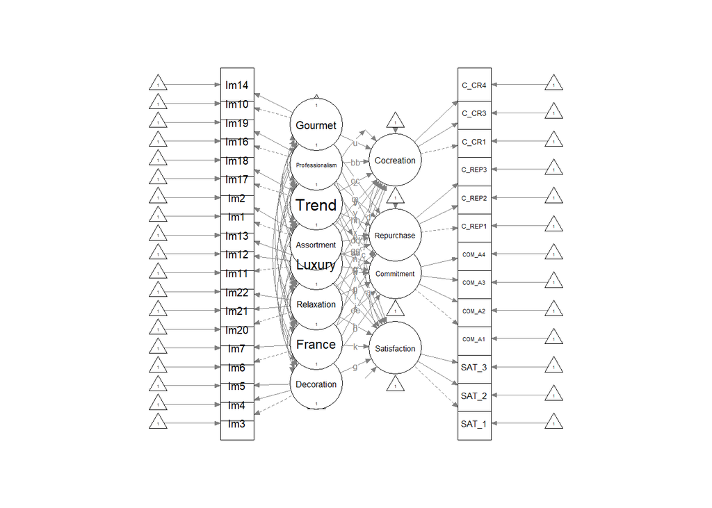

```r
semPaths(fit2, nCharNodes = 0, style = "lisrel", rotation = 2)
```

Note that `te` stands for total effects and `tie` for total indirect effects.

Let’s have a look at some coefficients/values to estimate the global fit measures.

1. First we look at the RMSEA value to see if it’s lower or equal to 0.05 to be a good fit. (Hu & Bentler (1999) suggest a cut off value of 0.06 before one can conclude that there is a good fit between model and data.) Here, the RMSEA is 0.033 so we have a very good fit.
2. We can look at a ratio of the Model Test User Model, if (Test statistic / Degrees of freedom) < 5, the fit is good. As noted from the lecture, ratio Chi2-value/df should be below 5 for samples up to 1000. Here, we note that we have 553 observation though. In our case, the Chi-square test: 632.247/399 = 1.584579 => the fit is good.
3. Regarding the User Model versus Baseline Model, if the Comparative Fit Index (CFI) is > 0.95, we accept the model. Here, the CFI is equal to 0.975, so we can accept our model. The Robust Comparative Fit Index (CFI) is even higher 0.977.

Our three global fit measures are very satisfactory!

### 2.1. Are the mechanism driving the 2 outcome similar?

As can be seen in the `Regression` section of the output and by looking at the standardized coefficient column, the `Affective Commitment` and `Customer Satisfaction` (our 2 mediators) are highly significant to explain the Cocreation Intention (p-value of respectively 0.012 and 0.000).Affective Commitment has a positive impact (0.377) and Customer Satisfaction a negative impact (-0.190) . We could say the more the customer is satisfied, the less the customer would be willing to participate in the cocreation process.

The `Affective Commitment` and `Customer Satisfaction` (our 2 mediators) are highly significant to explain the `Repurchase Intention` as well (p-value of respectively 0.000 and 0.000). `Affective Commitment` has a positive impact (0.354) and `Customer Satisfaction` a positive impact (0.318). We note that the impact is higher for the `Affective Commitment` than `Customer Satisfaction`.

So we would say that the mechanism driving the 2 outcomes aren’t really similar, due to `Customer Satisfaction` negatively impacting the outcome `Cocreation Intention`, while the same mediator has a positive impact on the outcome `Repurchase Intention`

### 2.2. Are `Customer Satisfaction` and `Affective Commitment` mediating the impact of image perceptions on outcomes? If yes, for which each of them?

We do this by look at whether the significant levels (via p-values) of all the modelled effects (direct and indirect) in the `Defined Parameters` section of the output.

We can see that the following effects are statistically significant (p-value < 0.05).

`af`, `ag`, `al`, `bp`, `bs`, `cf`, `cl`, `dp`, `ds`, `te4`, `te12`, `tie4`, `tie7`, `tie10`, `tie12`, `tie15` and `tie16`.

We can see that for some of them, the p-value is extremely significant (p-value of 0.000 for `bp`, `dp`, `te4`, `te12`, `tie4` and `tie12`). We will describe only two significant coefficient for an illustration purpose.

For instance, `af` (with a positive coefficient of 0.029 with a p-value of 0.027) corresponds to a path `Assortment–> Customer Satisfaction –> Repurchase Intention`, we could say that more the customer is happy with the Assortment, the more the client would be satisfied and it would increase the likelihood of buying again at the Galeries Lafayette. We could say that `Customer Satisfaction` mediates the impact of `Assortment` on the `Repurchase Intention`.

Second example, `cf` (with a negative coefficient of -0.048 with a p-value of 0.039) corresponds to a path `Assortment –> Customer Satisfaction –> Cocreation Intention`, we could say that more the customer is happy with the Assortment, the more the client would be satisfied and it would decrease the likelihood of participating again in cocreation activities at the Galeries Lafayette. We could say that `Customer Satisfaction` mediates the impact of `Assortment` on the `Cocreation Intentions`. Also the following paths are significant:

We could say that Customer Satisfaction mediates the impact of Decoration and Professionalism on the repurchase intention activities:

`ag`: `Decoration –> Customer Satisfaction –> Repurchase Intention`

`al`: `Professionalism –> Customer Satisfaction –> Repurchase Intention`

We could say that Affective Commitment mediates the impact of Relaxation and France on the repurchase intention activities:

`bp`: `Relaxation –> Affective Commitment –> Repurchase Intention`

`bs`: `France –> Affective Commitment –> Repurchase Intention`

We could say that Customer Satisfaction mediates the impact of Professionalism on the cocreation intention activities:

`cl`: `Professionalism –> Customer Satisfaction –> Cocreation Intentions`

We could say that Affective Commitment mediates the impact of Relaxation and France on the Cocreation intention activities:

`dp`: `Relaxation –> Affective Commitment –> Cocreation Intentions`

`ds`: `France –> Affective Commitment –> Cocreation Intentions`

Moreover, we can see that no Images from 1 to 22 have significant impact on our 2 outcomes (Cocreation Intention and Repurchase Intention).

### 3.1. What is driving the two distinct outcomes ?

We already answered a bit to this question previously but we will try to develop a bit more.

If we understood the question correctly, we note that regarding the Cocreation Intention, we have the same amount of significant coefficients for Affective Commitment and Customer Satisfaction (respectively dp, ds and cf,cl). However, regarding the Repurchase Intention, we have the more significant coefficients for Customer Satisfaction than Affective Commitment (respectively af, ag, al and bp, bs).

However, as we previously said, with regards to Cocreation Intention, Affective Commitment has a positive impact (0.377 - looking at the standardized coefficient column) and Customer Satisfaction a negative impact (-0.190), the Galeries Lafayettes should mostly try to improve their Affective Commitment and not the Customer Satisfaction because it would be counter-productive.

Also as previously said, with regards to `Repurchase Intention`, Affective Commitment has a positive impact (0.354) and Customer Satisfaction also has a positive impact (0.318). We note that the impact is higher from Affective Commitment on Repurchase Intention than the impact of Customer Satisfaction on Repurchase Intention. The Galeries Lafayettes should try to improve both these mediators but with a bit more emphasis on Affective Commitment.

### 3.2. Which image dimensions have the largest total effect on each of them?

Based on this, we see that:

- Regarding `Repurchase Intention`, image dimension `Relaxation` has the largest total effect.
- Regarding `Cocreation Intention`, image dimension `Relaxation` also has the largest total effect.